# Data Visualization Analysis

**We’ll use the object-oriented approach** because: - More explicit and readable - Better for complex visualizations - Industry best practice - Easier to customize

**Your First Matplotlib Visualization**

**The Basic Workflow:**

Every Matplotlib visualization follows these steps:

1. Import the library
2. Prepare your data
3. Create figure and axes
4. Plot the data
5. Display the plot

**Creating a Simple Line Plot:**

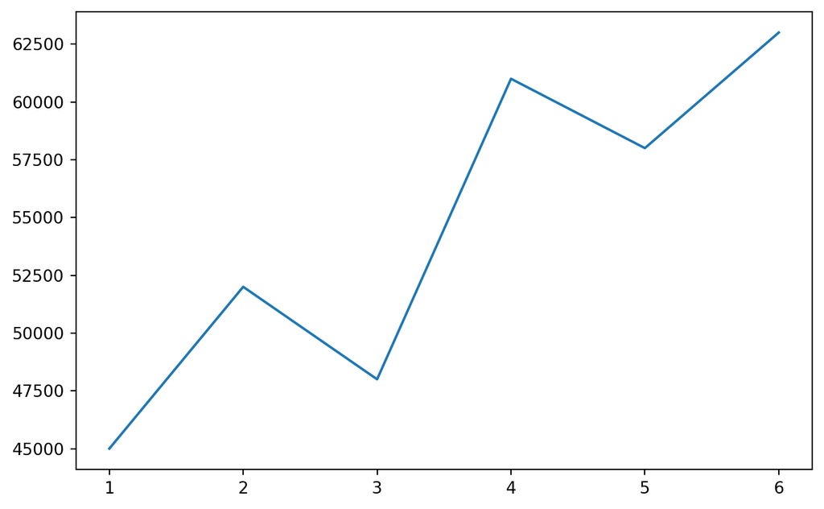

```python
import matplotlib.pyplot as plt

# Step 1: Prepare data (monthly sales)
months = [1, 2, 3, 4, 5, 6]
sales = [45000, 52000, 48000, 61000, 58000, 63000]

# Step 2: Create figure and axes
fig, ax = plt.subplots(figsize=(8, 5))

# Step 3: Create the plot
ax.plot(months, sales)

# Step 4: Display
plt.show()
```

**Output:**

*[Line chart]*

**What’s Happening:**

- `months` goes on the x-axis (horizontal)
- `sales` goes on the y-axis (vertical)
- `plot()` connects the points with lines
- `show()` displays the visualization

**The plt.show() Command:**

- In scripts: Required to display the plot window
- In Jupyter notebooks: Optional (plots display automatically)
- Pauses program execution until you close the plot window

**Line Plots - Showing Trends Over Time**

**When to Use Line Plots:**

Line plots are ideal for:

- **Time series data**: Sales over months, stock prices over days
- **Trends**: Showing direction of change
- **Continuous data**: Temperature, revenue, website traffic
- **Comparisons over time**: This year vs. last year

**Not good for:**

- Categorical comparisons (use bar charts)
- Part-to-whole relationships (use pie charts)
- Distributions (use histograms)

**Anatomy of a Line Plot:**

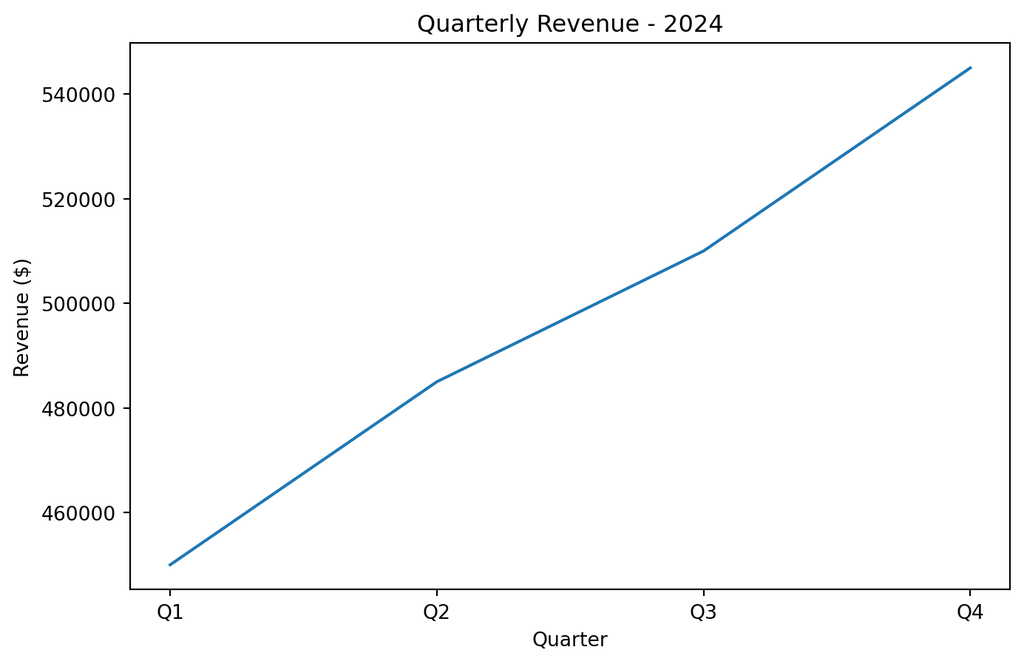

```python
import matplotlib.pyplot as plt

# Quarterly revenue data
quarters = ['Q1', 'Q2', 'Q3', 'Q4']
revenue = [450000, 485000, 510000, 545000]

# Create plot
fig, ax = plt.subplots(figsize=(8, 5))
ax.plot(quarters, revenue)

# Add labels (critical for business context)
ax.set_xlabel('Quarter')
ax.set_ylabel('Revenue ($)')
ax.set_title('Quarterly Revenue - 2024')

plt.show()
```

**Output:**

*[Line chart: “Quarterly Revenue - 2024”, x: Quarter, y: Revenue ($)]*

**Essential Plot Elements:**

- **Title**: What is this chart showing? (Always include!)
- **X-axis label**: What does the horizontal axis represent?
- **Y-axis label**: What does the vertical axis represent? (Include units!)
- **Data**: The actual line connecting points

**Improving Readability:**

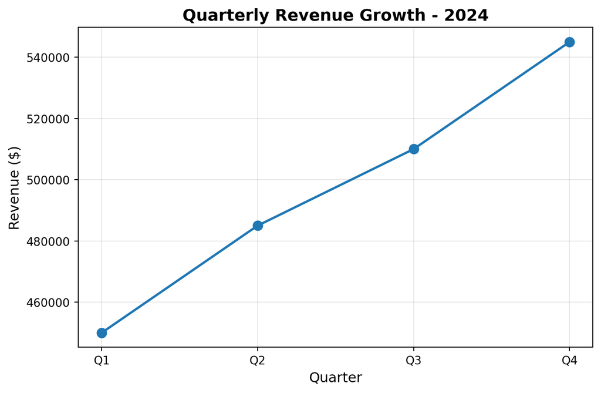

```python
import matplotlib.pyplot as plt

quarters = ['Q1', 'Q2', 'Q3', 'Q4']
revenue = [450000, 485000, 510000, 545000]

fig, ax = plt.subplots(figsize=(8, 5))

# Plot with markers to emphasize data points
ax.plot(quarters, revenue, marker='o', linewidth=2, markersize=8)

ax.set_xlabel('Quarter', fontsize=12)
ax.set_ylabel('Revenue ($)', fontsize=12)
ax.set_title('Quarterly Revenue Growth - 2024', fontsize=14, fontweight='bold')

# Add grid for easier reading
ax.grid(True, alpha=0.3)

plt.show()
```

**Output:**

*[Line chart: “Quarterly Revenue Growth - 2024”, x: Quarter, y: Revenue ($)]*

**Parameter Explanations:**

- `marker='o'`: Adds circular markers at data points
- `linewidth=2`: Makes the line thicker (default is 1)
- `markersize=8`: Controls size of markers
- `grid(True, alpha=0.3)`: Adds grid lines with 30% opacity

**Scatter Plots - Showing Relationships**

**When to Use Scatter Plots:**

Scatter plots reveal relationships between two variables:

- **Correlation**: Does advertising spend correlate with sales?
- **Outliers**: Which customers have unusual behavior?
- **Clustering**: Do data points group together?
- **Distribution**: How spread out are the values?

**Business Examples:**

- Price vs. Sales Volume
- Marketing Spend vs. Revenue
- Employee Experience vs. Salary
- Customer Age vs. Purchase Amount

**Creating a Scatter Plot:**

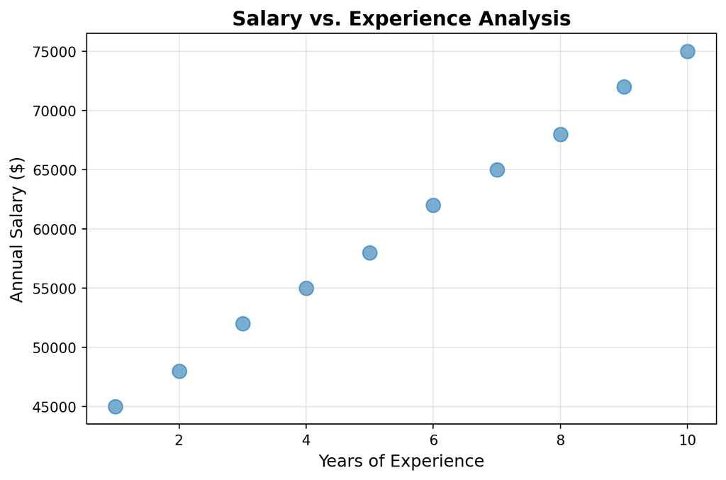

```python
import matplotlib.pyplot as plt

# Employee data: years of experience vs. salary
experience = [1, 2, 3, 4, 5, 6, 7, 8, 9, 10]
salary = [45000, 48000, 52000, 55000, 58000, 62000, 65000, 68000, 72000, 75000]

fig, ax = plt.subplots(figsize=(8, 5))

# Use scatter instead of plot
ax.scatter(experience, salary, s=100, alpha=0.6)

ax.set_xlabel('Years of Experience', fontsize=12)
ax.set_ylabel('Annual Salary ($)', fontsize=12)
ax.set_title('Salary vs. Experience Analysis', fontsize=14, fontweight='bold')

ax.grid(True, alpha=0.3)
plt.show()
```

**Output:**

*[Scatter plot: “Salary vs. Experience Analysis”, x: Years of Experience, y: Annual Salary ($)]*

**Scatter Plot Parameters:**

- `s=100`: Size of markers (s stands for size)
- `alpha=0.6`: Transparency (0=invisible, 1=opaque)
- No lines connecting points (unlike line plots)

**Reading Scatter Plots:**

What to look for:

- **Positive correlation**: Points trend upward (as X increases, Y increases)
- **Negative correlation**: Points trend downward (as X increases, Y decreases)
- **No correlation**: Points scattered randomly
- **Outliers**: Points far from the general pattern

**Choosing Between Line and Scatter Plots**

**Decision Framework:**

Use **Line Plots** when:

- X-axis represents time or sequential order
- You want to emphasize trends
- Connecting points makes sense
- Example: Monthly sales, daily temperature, yearly growth

Use **Scatter Plots** when:

- Investigating relationships between two variables
- Each point is an independent observation
- Connecting points doesn’t make sense
- Example: Height vs. Weight, Age vs. Income, Price vs. Demand

**The Same Data, Different Stories:**

Imagine plotting store locations by (Latitude, Longitude):

- Scatter plot: Shows geographic distribution
- Line plot: Would incorrectly suggest a path between stores

**Saving Your Visualizations**

**Why Save Plots:**

In business, you’ll need to:

- Include charts in reports (Word, PowerPoint)
- Share visualizations via email
- Post on internal dashboards
- Archive for compliance

**Saving to File:**

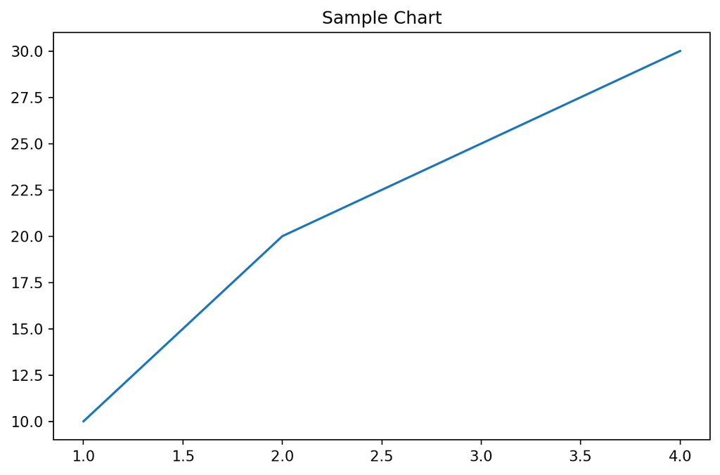

```python
import matplotlib.pyplot as plt

# Create your plot
fig, ax = plt.subplots(figsize=(8, 5))
ax.plot([1, 2, 3, 4], [10, 20, 25, 30])
ax.set_title('Sample Chart')

# Save before plt.show()
plt.savefig('monthly_sales.png', dpi=300, bbox_inches='tight')
plt.show()
```

**Output:**

*[Line chart: “Sample Chart”]*

**Important Parameters:**

- `dpi=300`: Resolution (300 is publication quality, 150 is screen quality)
- `bbox_inches='tight'`: Removes extra whitespace around the plot
- File extension determines format: .png, .pdf, .jpg, .svg

**Format Guide:**

- **PNG**: Best for reports, presentations, web (our go-to choice)
- **PDF**: Vector format, scales perfectly, good for print
- **JPG**: Smaller files but lower quality
- **SVG**: Vector format, editable in design software

**File Naming Best Practices:**

- Descriptive: `Q4_2024_Sales_Trend.png` not `plot1.png`
- Include date if relevant: `Revenue_2024_12_15.png`
- No spaces: Use underscores or hyphens

### 2.1.3 Lab Session

**Lab 1: Creating Your First Business Visualizations**

**Objective:** Master the fundamentals of Matplotlib by creating line plots and scatter plots for real business scenarios.

**Scenario:** You work for “TechGadget Inc.,” an electronics retailer. The marketing director has requested visualizations to present at the upcoming board meeting. You’ll create professional charts analyzing sales performance and customer patterns.

**Pre-Lab Setup:**

1. Create a new file: `M2L01_YourName_FirstPlots.py`
2. Import necessary libraries at the top
3. Create a folder called “Lab1_Outputs” to save your charts

**Part A: Monthly Sales Trend Analysis (25 points)**

**Context:** Your company’s sales for the first half of 2024 need to be visualized to show the board how performance has trended.

**Data:**

- Months: January through June
- Sales: $125,000, $142,000, $138,000, $156,000, $151,000, $168,000

**Tasks:**

1. **Create a basic line plot (10 points):**
   - Use the object-oriented approach (fig, ax = plt.subplots())
   - Set figure size to (12, 6) for presentation format
   - Plot months on x-axis and sales on y-axis
   - Display the plot
2. **Add professional formatting (10 points):**
   - Add clear title: “TechGadget Inc. - H1 2024 Sales Performance”
   - Label x-axis: “Month”
   - Label y-axis: “Sales Revenue ($)”
   - Increase font sizes (title: 14pt bold, labels: 12pt)
   - Add markers at each data point with size 10
   - Make line thickness 2.5
   - Add a light grid for readability
3. **Save the visualization (5 points):**
   - Save as: “M2L01_YourName_MonthlySales.png”
   - Use high resolution (dpi=300)
   - Remove extra whitespace (bbox_inches=‘tight’)

**Expected Outcome:** A professional line chart suitable for presentation that clearly shows sales growth over 6 months.

**Part B: Product Price vs. Sales Analysis (30 points)**

**Context:** The product team wants to understand if there’s a relationship between product price and units sold to optimize pricing strategy.

**Data:**

Ten products with their prices and units sold: - Prices: $25, $45, $120, $85, $199, $350, $75, $450, $150, $299 - Units Sold: 850, 720, 245, 380, 180, 95, 425, 68, 210, 125

**Tasks:**

1. **Create a scatter plot (12 points):**
   - Figure size: (10, 8)
   - Plot price on x-axis and units sold on y-axis
   - Use scatter plot (not line plot)
   - Set marker size to 150
   - Set transparency (alpha) to 0.7
2. **Format for analysis (12 points):**
   - Title: “Product Price vs. Sales Volume Analysis”
   - X-axis label: “Product Price ($)” with font size 12
   - Y-axis label: “Units Sold” with font size 12
   - Title font size: 14pt, bold
   - Add a grid with 30% opacity
   - Use a color other than blue for markers (e.g., ‘green’, ‘red’, ‘orange’)
3. **Interpret and annotate (6 points):**
   - Look at your scatter plot
   - In a comment in your code, write 2-3 sentences describing:
     - What relationship (if any) do you see between price and units sold?
     - Are there any outlier products?
     - What business insight does this provide?

**Part C: Comparative Analysis (25 points)**

**Context:** The CEO wants to compare this year’s performance against last year to see if the company is improving.

**Data:**

- Months: Jan, Feb, Mar, Apr, May, Jun
- 2023 Sales: $118,000, $125,000, $130,000, $135,000, $140,000, $145,000
- 2024 Sales: $125,000, $142,000, $138,000, $156,000, $151,000, $168,000

**Tasks:**

1. **Create a comparison line plot (15 points):**
   - Figure size: (12, 6)
   - Plot BOTH years on the same chart
   - 2023 line should be one color with one marker style
   - 2024 line should be a different color with different marker style
   - Both lines should have thickness 2
   - Markers should be size 8
2. **Add distinguishing features (10 points):**
   - Title: “Year-over-Year Sales Comparison: 2023 vs 2024”
   - Proper axis labels with units
   - Legend showing which line is which year
     - Use: `ax.legend(['2023', '2024'], fontsize=11)`
   - Grid for readability
   - Save as: “M2L01_YourName_YearComparison.png”

**Part D: Customer Age vs. Purchase Amount (20 points)**

**Context:** Marketing wants to understand if customer age correlates with purchase amount to target advertising appropriately.

**Data:**

- Customer Ages: 22, 35, 45, 28, 52, 38, 29, 48, 33, 41, 26, 55, 31, 44, 37
- Purchase Amounts: $85, $245, $420, $165, $580, $310, $190, $495, $225, $380, $140, $625, $210, $450, $290

**Tasks:**

1. **Create an analytical scatter plot (15 points):**
   - Figure size: (10, 7)
   - Appropriate title and axis labels
   - Marker size: 120
   - Use a professional color (not default blue)
   - Add transparency
   - Include grid
2. **Save and analyze (5 points):**
   - Save as: “M2L01_YourName_AgeAnalysis.png”
   - In comments, answer:
     - Is there a correlation between age and purchase amount?
     - What age group spends the most?
     - What recommendation would you make to marketing?

**Bonus Challenge (+10 points):**

Create one additional visualization of your choice using the provided data or your own business scenario: - Must use either line or scatter plot appropriately - Must be professionally formatted - Must include a business context (explain what it shows and why it matters) - Save as: “M2L01_YourName_Bonus.png”

**Deliverables:**

1. Python file: `M2L01_YourName_FirstPlots.py` with all parts clearly commented
2. Four PNG files (three required + bonus if attempted):
   - `M2L01_YourName_MonthlySales.png`
   - `M2L01_YourName_YearComparison.png`
   - `M2L01_YourName_AgeAnalysis.png`
   - `M2L01_YourName_Bonus.png` (if bonus attempted)

**Grading Rubric:**

- Part A (Monthly Sales): 25 points
- Part B (Price vs. Sales): 30 points
- Part C (Year Comparison): 25 points
- Part D (Age Analysis): 20 points
- Bonus: +10 points

**Success Criteria:**

- All plots display correctly when code is run
- Professional formatting applied to all visualizations
- Files saved with correct names and high quality
- Appropriate plot types used for each scenario
- Business insights documented in comments
- Code is well-organized with clear comments

**Common Mistakes to Avoid:**

- Forgetting to save plots before plt.show()
- Missing axis labels or titles
- Using line plots for non-sequential data
- Poor color choices (too bright, hard to read)
- File names with spaces or unclear naming
- Not setting appropriate figure sizes

**Tips for Success:**

- Test each part separately before moving to the next
- View your saved PNG files to verify quality
- Use meaningful variable names
- Comment your code as you go
- If a plot looks wrong, check your data first
- Reference the section examples for syntax

## 2.2 Section 2: Customizing Visualizations (Colors, Labels, Legends)

### 2.2.1 Objective

- Master color selection for professional, accessible visualizations
- Apply comprehensive labeling strategies for business clarity
- Create and position legends effectively for multi-series plots
- Control text properties (fonts, sizes, styles) for readability
- Format axes and ticks for professional presentations
- Understand design principles for business communication

### 2.2.2 Main Contents with Examples

**The Importance of Customization in Business Context**

**Why Default Settings Aren’t Enough:**

Matplotlib’s default visualizations are functional but generic. In business contexts, customization is essential because:

**1. Branding and Professionalism:**

- Corporate reports require company colors
- Presentations need consistent visual identity
- Professional appearance builds credibility

**2. Accessibility:**

- Default colors may not be colorblind-friendly
- Text might be too small for presentations
- Poor contrast makes charts unreadable

**3. Clarity:**

- Generic labels don’t provide business context
- Missing legends confuse viewers
- Poorly formatted numbers obscure insights

**4. Storytelling:**

- Colors can emphasize important data
- Annotations guide attention
- Formatting reinforces key messages

**The Professional Standard:**

Compare these descriptions:

- **Default**: Blue line, “x” label, “y” label
- **Professional**: Corporate blue (#1f77b4), “Fiscal Year 2024”, “Revenue (Millions USD)”, clear legend, formatted axis ticks, appropriate title

The second version communicates authority and attention to detail.

**Working with Colors Effectively**

**Understanding Color in Matplotlib:**

Colors in Matplotlib can be specified multiple ways:

1. **Named colors**: ‘red’, ‘blue’, ‘green’ (140 named colors available)
2. **Hex codes**: ‘#1f77b4’ (web standard)
3. **RGB tuples**: (0.5, 0.2, 0.8) (values 0-1)
4. **Built-in color maps**: ‘viridis’, ‘plasma’, ‘tab10’

**Basic Color Application:**

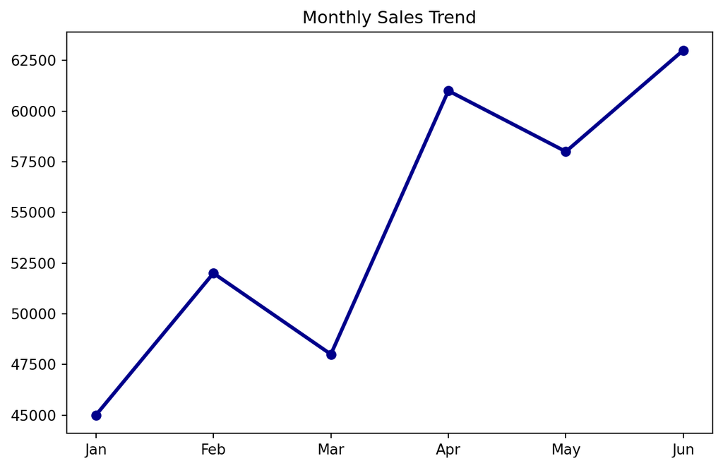

```python
import matplotlib.pyplot as plt

months = ['Jan', 'Feb', 'Mar', 'Apr', 'May', 'Jun']
sales = [45000, 52000, 48000, 61000, 58000, 63000]

fig, ax = plt.subplots(figsize=(8, 5))

# Specify color
ax.plot(months, sales, color='darkblue', linewidth=2.5, marker='o')

ax.set_title('Monthly Sales Trend')
plt.show()
```

**Output:**

*[Line chart: “Monthly Sales Trend”]*

**Common Business Color Choices:**

Different colors convey different meanings in business:

- **Blue shades**: Trust, professionalism, stability (most common in business)
  - Navy: ‘#000080’, Royal: ‘#4169E1’, Sky: ‘#87CEEB’
- **Green shades**: Growth, profit, positive performance
  - Forest: ‘#228B22’, Money: ‘#2E7D32’, Mint: ‘#98D8C8’
- **Red shades**: Loss, decline, urgent attention
  - Crimson: ‘#DC143C’, Burgundy: ‘#800020’
- **Gray shades**: Neutral, supporting information
  - Dark: ‘#4A4A4A’, Medium: ‘#808080’, Light: ‘#D3D3D3’
- **Orange/Yellow**: Caution, moderate concern, highlights
  - Gold: ‘#FFD700’, Amber: ‘#FFBF00’

**Color Psychology in Business Charts:**

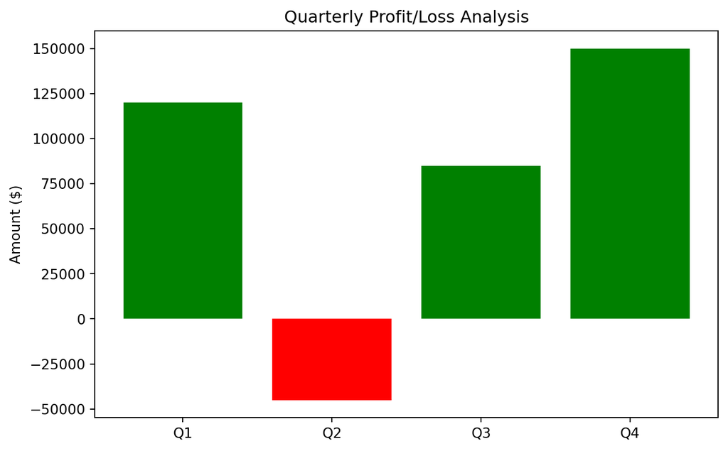

```python
# Profit/Loss visualization
months = ['Q1', 'Q2', 'Q3', 'Q4']
profit = [120000, -45000, 85000, 150000]

fig, ax = plt.subplots(figsize=(8, 5))

# Color bars based on profit/loss
colors = ['green' if p > 0 else 'red' for p in profit]
ax.bar(months, profit, color=colors)

ax.set_title('Quarterly Profit/Loss Analysis')
ax.set_ylabel('Amount ($)')
plt.show()
```

**Output:**

*[Bar chart: “Quarterly Profit/Loss Analysis”, y: Amount ($)]*

**Accessibility: Colorblind-Friendly Palettes:**

Approximately 8% of men and 0.5% of women have color vision deficiency. Use colorblind-safe palettes:

**Good combinations:**

- Blue and Orange
- Blue and Yellow
- Purple and Green

**Avoid:**

- Red and Green (most common colorblindness)
- Red and Brown
- Blue and Purple (for some types)

**Using Colorblind-Friendly Palettes:**

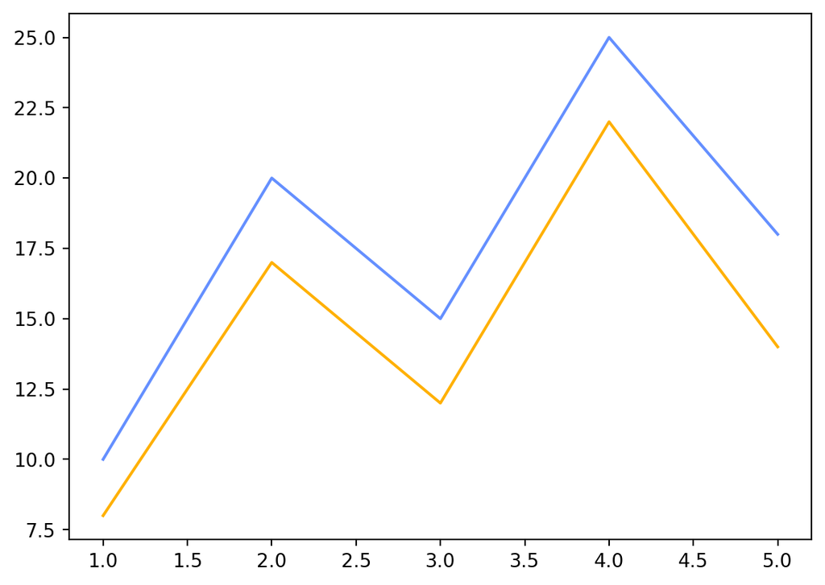

```python
# IBM's colorblind-safe palette
colors = ['#648FFF', '#FFB000', '#DC267F', '#FE6100', '#785EF0']

# Sample data for demonstration
x = [1, 2, 3, 4, 5]
y = [10, 20, 15, 25, 18]
y2 = [8, 17, 12, 22, 14]

fig, ax = plt.subplots()

# Or use built-in safe colormaps
ax.plot(x, y, color='#648FFF')  # Blue
ax.plot(x, y2, color='#FFB000')  # Orange
plt.show()
```

**Output:**

*[Line chart]*

**Comprehensive Labeling Strategies**

**The Three Essential Labels:**

Every business visualization must have:

1. **Title**: What is this chart showing?
2. **X-axis label**: What does the horizontal axis represent?
3. **Y-axis label**: What does the vertical axis represent?

**Missing any of these makes your chart ambiguous and unprofessional.**

**Creating Effective Titles:**

Titles should be:

- **Specific**: Not “Sales Chart” but “Regional Sales Performance Q4 2024”
- **Informative**: Tell what, when, where if relevant
- **Concise**: One line preferred, two maximum
- **Professional**: Avoid casual language

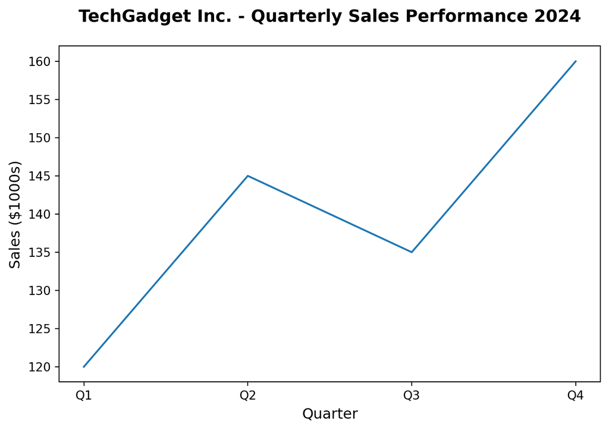

```python
import matplotlib.pyplot as plt

data = [120, 145, 135, 160]
quarters = ['Q1', 'Q2', 'Q3', 'Q4']

fig, ax = plt.subplots(figsize=(8, 5))
ax.plot(quarters, data)

# Poor title:
# ax.set_title('Sales')

# Better title:
# ax.set_title('Sales Data')

# Best title:
ax.set_title('TechGadget Inc. - Quarterly Sales Performance 2024',
             fontsize=14, fontweight='bold', pad=20)

ax.set_xlabel('Quarter', fontsize=12)
ax.set_ylabel('Sales ($1000s)', fontsize=12)

plt.show()
```

**Output:**

**Title Parameters Explained:**

- `fontsize=14`: Larger than body text (12) to emphasize
- `fontweight='bold'`: Makes title stand out
- `pad=20`: Adds space between title and plot (default is 6)

**Axis Label Best Practices:**

**Always include units:**

- Not: “Revenue”
- But: “Revenue ($ Millions)” or “Revenue ($)” or “Temperature (°F)”

**Be specific:**

- Not: “Time”
- But: “Month” or “Fiscal Quarter” or “Week Number”

**Use appropriate precision:**

- If numbers are in thousands: “Sales ($1000s)” or “Sales (Thousands)”
- If numbers are percentages: “Market Share (%)”

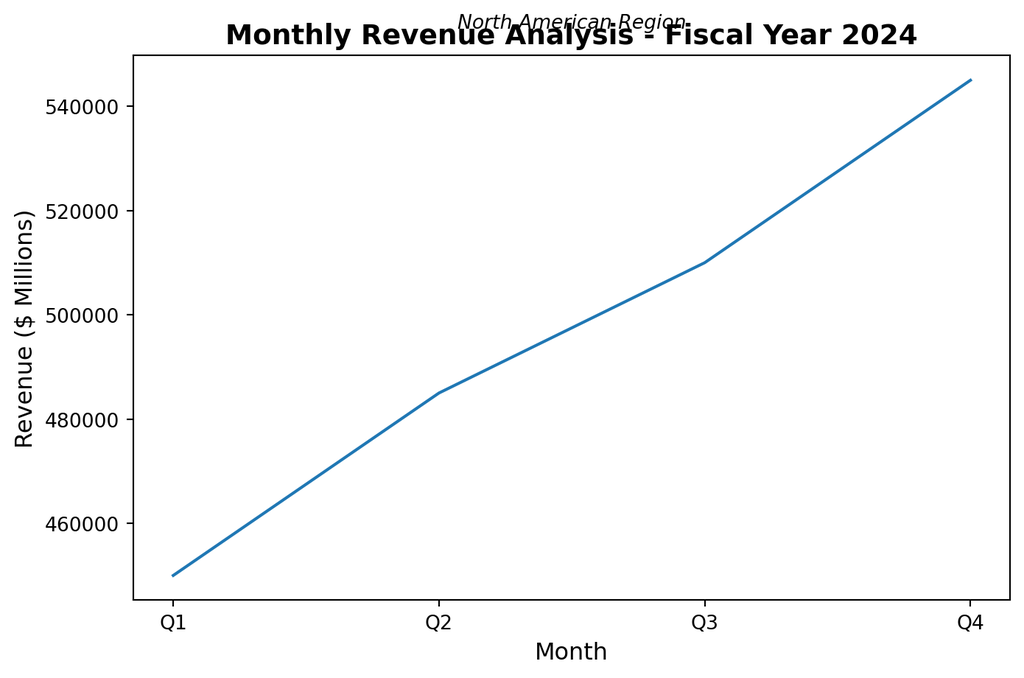

```python
# Complete labeling example
fig, ax = plt.subplots(figsize=(8, 5))
ax.plot(months, revenue)

ax.set_title('Monthly Revenue Analysis - Fiscal Year 2024',
             fontsize=14, fontweight='bold')
ax.set_xlabel('Month', fontsize=12, fontweight='medium')
ax.set_ylabel('Revenue ($ Millions)', fontsize=12, fontweight='medium')

# Add subtitle if needed (smaller text below title)
ax.text(0.5, 1.05, 'North American Region',
        transform=ax.transAxes, ha='center', fontsize=10, style='italic')

plt.show()
```

**Output:**

*[Line chart: “Monthly Revenue Analysis - Fiscal Year 2024”, x: Month, y: Revenue ($ Millions)]*